# Assignment-2_data_visualisation

```python
import pandas as pd
import numpy as np
import matplotlib.pyplot as plt
import seaborn as sns
```

```python
df=pd.read_csv("car_crashes.csv")
```

```python
df.head()
```

|  | Unnamed: 0 | total | speeding | alcohol | not_distracted | no_previous | ins_premium | ins_losses | abbrev |
| --- | --- | --- | --- | --- | --- | --- | --- | --- | --- |
| 0 | 0 | 18.8 | 7.332 | 5.640 | 18.048 | 15.040 | 784.55 | 145.08 | AL |
| 1 | 1 | 18.1 | 7.421 | 4.525 | 16.290 | 17.014 | 1053.48 | 133.93 | AK |
| 2 | 2 | 18.6 | 6.510 | 5.208 | 15.624 | 17.856 | 899.47 | 110.35 | AZ |
| 3 | 3 | 22.4 | 4.032 | 5.824 | 21.056 | 21.280 | 827.34 | 142.39 | AR |
| 4 | 4 | 12.0 | 4.200 | 3.360 | 10.920 | 10.680 | 878.41 | 165.63 | CA |

```python
df.shape
```

```
(51, 9)
```

##### total -> Number of drivers involved in fatal collisions per billion miles (5.900–23.900)

##### speeding -> Percentage Of Drivers Involved In Fatal Collisions Who Were Speeding (1.792–9.450)

##### alcohol -> Percentage Of Drivers Involved In Fatal Collisions Who Were Alcohol-Impaired (1.593–10.038)

##### not_distracted -> Percentage Of Drivers Involved In Fatal Collisions Who Were Not Distracted (1.760–23.661)

##### no_previous -> Percentage Of Drivers Involved In Fatal Collisions Who Had Not Been Involved In Any Previous Accidents (5.900–21.280)

##### ins_premium -> Car Insurance Premiums (641.960–1301.520)

##### ins_losses -> Losses incurred by insurance companies for collisions per insured driver (82.75–194.780)

##### abbrev -> USA states

```python
df["low premium/high premium"]=np.where(df["ins_premium"]<1000.0,"low","high")
df.head()
```

|  | Unnamed: 0 | total | speeding | alcohol | not_distracted | no_previous | ins_premium | ins_losses | abbrev | low premium/high premium |
| --- | --- | --- | --- | --- | --- | --- | --- | --- | --- | --- |
| 0 | 0 | 18.8 | 7.332 | 5.640 | 18.048 | 15.040 | 784.55 | 145.08 | AL | low |
| 1 | 1 | 18.1 | 7.421 | 4.525 | 16.290 | 17.014 | 1053.48 | 133.93 | AK | high |
| 2 | 2 | 18.6 | 6.510 | 5.208 | 15.624 | 17.856 | 899.47 | 110.35 | AZ | low |
| 3 | 3 | 22.4 | 4.032 | 5.824 | 21.056 | 21.280 | 827.34 | 142.39 | AR | low |
| 4 | 4 | 12.0 | 4.200 | 3.360 | 10.920 | 10.680 | 878.41 | 165.63 | CA | low |

```python
df.info()
```

```
<class 'pandas.core.frame.DataFrame'>
RangeIndex: 51 entries, 0 to 50
Data columns (total 10 columns):
 #   Column                    Non-Null Count  Dtype
---  ------                    --------------  -----
 0   Unnamed: 0                51 non-null     int64
 1   total                     51 non-null     float64
 2   speeding                  51 non-null     float64
 3   alcohol                   51 non-null     float64
 4   not_distracted            51 non-null     float64
 5   no_previous               51 non-null     float64
 6   ins_premium               51 non-null     float64
 7   ins_losses                51 non-null     float64
 8   abbrev                    51 non-null     object
 9   low premium/high premium  51 non-null     object
dtypes: float64(7), int64(1), object(2)
memory usage: 4.1+ KB
```

```python
df.describe()
```

|  | Unnamed: 0 | total | speeding | alcohol | not_distracted | no_previous | ins_premium | ins_losses |
| --- | --- | --- | --- | --- | --- | --- | --- | --- |
| count | 51.000000 | 51.000000 | 51.000000 | 51.000000 | 51.000000 | 51.000000 | 51.000000 | 51.000000 |
| mean | 25.000000 | 15.790196 | 4.998196 | 4.886784 | 13.573176 | 14.004882 | 886.957647 | 134.493137 |
| std | 14.866069 | 4.122002 | 2.017747 | 1.729133 | 4.508977 | 3.764672 | 178.296285 | 24.835922 |
| min | 0.000000 | 5.900000 | 1.792000 | 1.593000 | 1.760000 | 5.900000 | 641.960000 | 82.750000 |
| 25% | 12.500000 | 12.750000 | 3.766500 | 3.894000 | 10.478000 | 11.348000 | 768.430000 | 114.645000 |
| 50% | 25.000000 | 15.600000 | 4.608000 | 4.554000 | 13.857000 | 13.775000 | 858.970000 | 136.050000 |
| 75% | 37.500000 | 18.500000 | 6.439000 | 5.604000 | 16.140000 | 16.755000 | 1007.945000 | 151.870000 |
| max | 50.000000 | 23.900000 | 9.450000 | 10.038000 | 23.661000 | 21.280000 | 1301.520000 | 194.780000 |

```python
df.drop(columns=["Unnamed: 0","abbrev"],inplace=True) #unnamed and abbrev not important
```

```python
df.head()
```

|  | total | speeding | alcohol | not_distracted | no_previous | ins_premium | ins_losses | low premium/high premium |
| --- | --- | --- | --- | --- | --- | --- | --- | --- |
| 0 | 18.8 | 7.332 | 5.640 | 18.048 | 15.040 | 784.55 | 145.08 | low |
| 1 | 18.1 | 7.421 | 4.525 | 16.290 | 17.014 | 1053.48 | 133.93 | high |
| 2 | 18.6 | 6.510 | 5.208 | 15.624 | 17.856 | 899.47 | 110.35 | low |
| 3 | 22.4 | 4.032 | 5.824 | 21.056 | 21.280 | 827.34 | 142.39 | low |
| 4 | 12.0 | 4.200 | 3.360 | 10.920 | 10.680 | 878.41 | 165.63 | low |

## Distribution plots

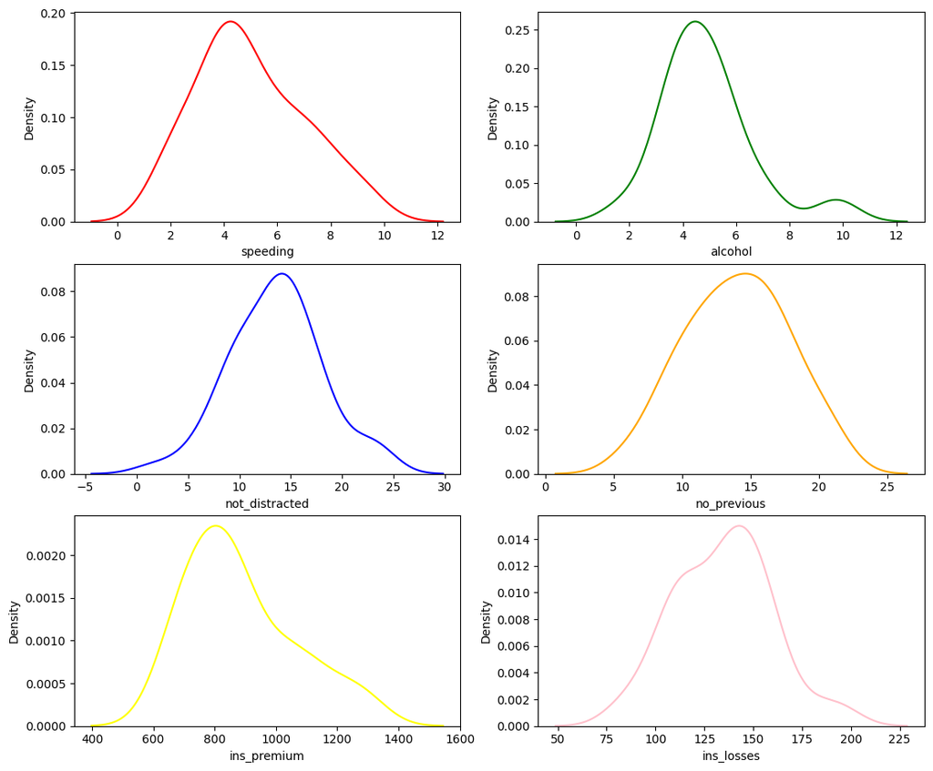

```python
plt.figure(figsize=(13,11))
plt.subplot(3,2,1)
sns.kdeplot(df["speeding"],color="red")
plt.subplot(3,2,2)
sns.kdeplot(df["alcohol"],color="green")
plt.subplot(3,2,3)
sns.kdeplot(df["not_distracted"],color="blue")
plt.subplot(3,2,4)
sns.kdeplot(df["no_previous"],color="orange")
plt.subplot(3,2,5)
sns.kdeplot(df["ins_premium"],color="yellow")
plt.subplot(3,2,6)
sns.kdeplot(df["ins_losses"],color="pink")
plt.show()
```

###### fifth plot representing the Car Insurance Premiums per driver are more between 750 and 830

###### sixth plot representing the Losses incurred by insurance companies for collisions per insured driver are more between 137 and 155

## Histogram

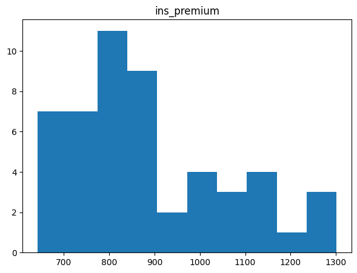

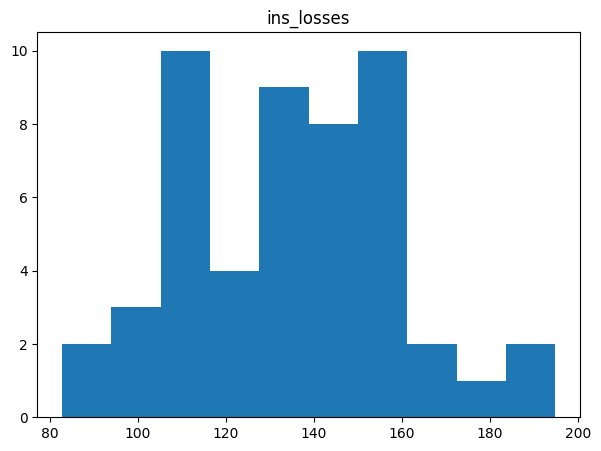

```python
plt.figure(figsize=(7,5))
plt.hist(df["ins_premium"])
plt.title("ins_premium")
plt.show()
plt.figure(figsize=(7,5))
plt.hist(df["ins_losses"])
plt.title("ins_losses")
plt.show()
```

##### in first plot we can observe that ins premium per driver is more between 750 and 830

##### in second plot ins losses incurred by company are more between 150 and 160

## Box plot

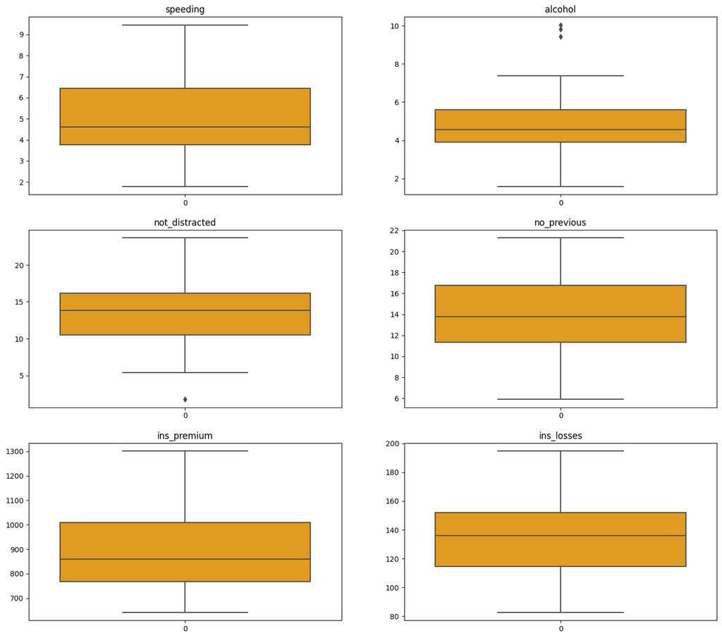

```python
plt.figure(figsize=(17,15))
for i in range(1,len(df.columns)-1):
    plt.subplot(3,2,i)
    sns.boxplot(df.iloc[:,i],color="orange")
    plt.title(df.columns[i])
plt.show()
```

## Pie plot

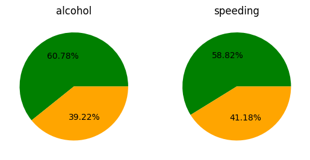

```python
plt.subplot(1,2,1)
plt.pie([df[df["alcohol"]<5.0].shape[0],df[df["alcohol"]>=5.0].shape[0]], colors=["green","orange"],autopct="%1.2f%%")
plt.title("alcohol")
plt.subplot(1,2,2)
plt.pie([df[df["speeding"]<5.0].shape[0],df[df["speeding"]>=5.0].shape[0]],colors=["green","orange"], autopct="%1.2f%%")
plt.title("speeding")
plt.show()
```

##### first pie representing the percentage of states with less than 5% of drivers involved in collision due to alcohol is higher than percentage of states with greater than 5% of acidents drivers involved in collision due to alcohol

##### second pie representing the percentage of states with less than 5% of drivers involved in collision due to speeding is higher than percentage of states with greater than 5% of acidents drivers involved in collision due to speeding

## Bar plot

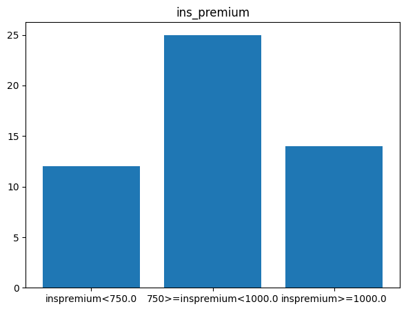

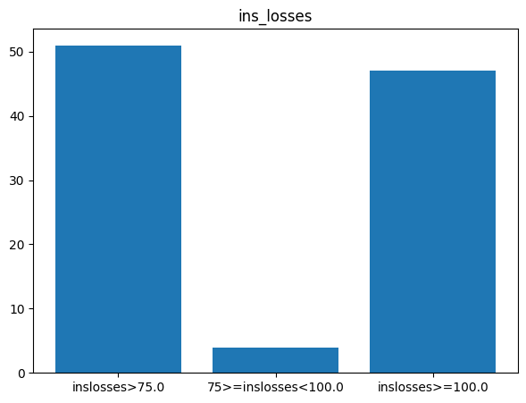

```python
plt.figure(figsize=(7,5))
plt.bar(["inspremium<750.0","750>=inspremium<1000.0","inspremium>=1000.0"],[df[df["ins_premium"]<750.0].shape[0],
        df[(df["ins_premium"]>=750.0)&(df["ins_premium"]<1000.0)].shape[0],
        df[df["ins_premium"]>1000.0].shape[0]])
plt.title("ins_premium")
plt.show()
plt.figure(figsize=(7,5))
plt.bar(["inslosses>75.0","75>=inslosses<100.0","inslosses>=100.0"],[df[df["ins_losses"]>75.0].shape[0],
        df[(df["ins_losses"]>=75.0)&(df["ins_losses"]<100.0)].shape[0],
        df[df["ins_losses"]>100.0].shape[0]])
plt.title("ins_losses")
plt.show()
```

##### first plot representing insurance premium per driver is between 750 and 1000 has higher frequency

##### second plot representing that that insurance loss by company between 75 and 100 has less frequency comparitevely

## Strip plot

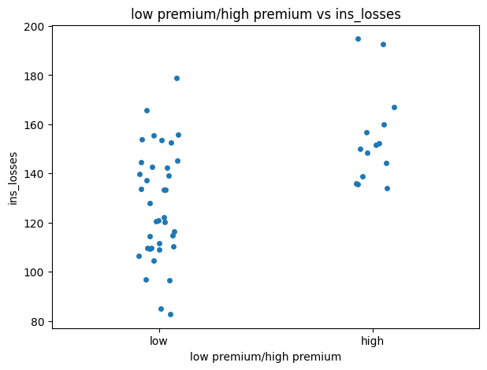

```python
plt.figure(figsize=(7,5))
sns.stripplot(data=df,x="low premium/high premium",y="ins_losses")
plt.title("low premium/high premium vs ins_losses")
plt.show()
```

##### from the plot we can observe that the drivers who pay insurance premiumns low are more than drivers who pay insurance premiumns high

##### And we can observe that loss incurred by company is high on drivers who pay insurance premiumns high